# Practical machine learning project

Sri Harsha Sriramakavacham

23/06/2020

## 1. Background and Problem statement

Many People are using devices such as Jawbone Up, Nike FuelBand, and Fitbit to track themselves regularly to improve their health. One thing that these people regularly do is quantify how much of a particular activity they do, but they rarely quantify how well they do it.

As a part of the practical machine learning project, our goal will be to use data from accelerometers on the belt, forearm, arm, and dumbell of 6 participants and quantify their performance using classe as the target variable

## 2. Loading packages and data

We have loaded caret (to run models) and ggplot2 packages (to creates plots) and also loaded the testing and training data

```r
library(caret)
```

```r
library(ggplot2)
library(dplyr)
library(readr)

training <- read.csv("~/project/pml-training.csv", na.strings = c("NA", "#DIV/0!", ""), stringsAsFactors = FALSE , header = TRUE)
testing <- read.csv("~/project/pml-testing.csv",  na.strings = c("NA", "#DIV/0!", ""),stringsAsFactors = FALSE , header = TRUE)
```

## 3. Exploring and cleaning data

We need to understand the data before performing any analysis, we do know that “classe” variable gives the classes and need to create a model using other variables in the data

```r
head(training)
```

```
##   X user_name raw_timestamp_part_1 raw_timestamp_part_2   cvtd_timestamp
## 1 1  carlitos           1323084231               788290 05/12/2011 11:23
## 2 2  carlitos           1323084231               808298 05/12/2011 11:23
## 3 3  carlitos           1323084231               820366 05/12/2011 11:23
## 4 4  carlitos           1323084232               120339 05/12/2011 11:23
## 5 5  carlitos           1323084232               196328 05/12/2011 11:23
## 6 6  carlitos           1323084232               304277 05/12/2011 11:23
##   new_window num_window roll_belt pitch_belt yaw_belt total_accel_belt
## 1         no         11      1.41       8.07    -94.4                3
## 2         no         11      1.41       8.07    -94.4                3
## 3         no         11      1.42       8.07    -94.4                3
## 4         no         12      1.48       8.05    -94.4                3
## 5         no         12      1.48       8.07    -94.4                3
## 6         no         12      1.45       8.06    -94.4                3
##   kurtosis_roll_belt kurtosis_picth_belt kurtosis_yaw_belt skewness_roll_belt
```

[output cut: 251 more lines]

```r
head(testing)
```

```
##   X user_name raw_timestamp_part_1 raw_timestamp_part_2   cvtd_timestamp
## 1 1     pedro           1323095002               868349 05/12/2011 14:23
## 2 2    jeremy           1322673067               778725 30/11/2011 17:11
## 3 3    jeremy           1322673075               342967 30/11/2011 17:11
## 4 4    adelmo           1322832789               560311 02/12/2011 13:33
## 5 5    eurico           1322489635               814776 28/11/2011 14:13
## 6 6    jeremy           1322673149               510661 30/11/2011 17:12
##   new_window num_window roll_belt pitch_belt yaw_belt total_accel_belt
## 1         no         74    123.00      27.00    -4.75               20
## 2         no        431      1.02       4.87   -88.90                4
## 3         no        439      0.87       1.82   -88.50                5
## 4         no        194    125.00     -41.60   162.00               17
## 5         no        235      1.35       3.33   -88.60                3
## 6         no        504     -5.92       1.59   -87.70                4
##   kurtosis_roll_belt kurtosis_picth_belt kurtosis_yaw_belt skewness_roll_belt
```

[output cut: 251 more lines]

We can see that the first 7 columns of the training and testing data can be removed as they show the name of the participants/date and other info that have little impat on the model. We also see that there are columns with “NA” and need to be removed from the analysis

```r
# Removing first 7 columns
training_1 <- training [-c(1:7)]
testing_1 <- testing [-c(1:7)]


#Removing columns with NA
training_2 <- training_1[, colSums(is.na(training_1)) == 0]
testing_2 <- testing_1[, colSums(is.na(testing_1)) == 0]


 dim(training_2)
```

```
## [1] 19622    53
```

```r
 dim(testing_2)
```

```
## [1] 20 53
```

```r
 table(training_2$classe)
```

```
##
##    A    B    C    D    E
## 5580 3797 3422 3216 3607
```

## 4. Data partition

```r
# Data partition
set.seed(2567)
inTrain <- createDataPartition(training_2$classe, p = 0.75)[[1]]
training_final <- training_2[inTrain,]
validation_final <- training_2[-inTrain,]

dim(training_final)
```

```
## [1] 14718    53
```

```r
dim(validation_final)
```

```
## [1] 4904   53
```

## 5.a. Prediction with decision tree

```r
library(rattle)
```

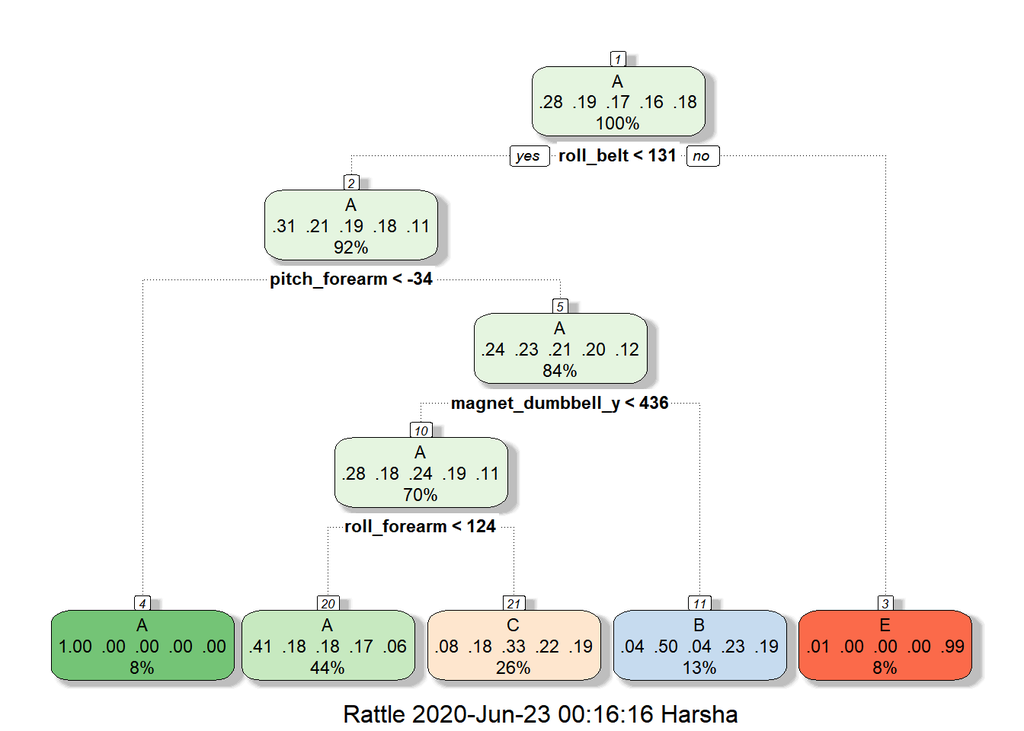

```r
library(e1071)

model_dt <- train(classe ~ ., data = training_final , method = "rpart")
fancyRpartPlot(model_dt$finalModel)
```

```r
prediction_dt <- predict(model_dt, newdata = validation_final)
cm_dt <- confusionMatrix(prediction_dt,as.factor(validation_final$classe))
cm_dt
```

```
## Confusion Matrix and Statistics
##
##           Reference
## Prediction    A    B    C    D    E
##          A 1256  389  397  343  124
##          B   31  330   26  139  137
##          C  105  230  432  322  239
##          D    0    0    0    0    0
##          E    3    0    0    0  401
##
## Overall Statistics
##
##                Accuracy : 0.4933
##                  95% CI : (0.4792, 0.5074)
##     No Information Rate : 0.2845
##     P-Value [Acc > NIR] : < 2.2e-16
##
##                   Kappa : 0.3384
##
##  Mcnemar's Test P-Value : NA
##
## Statistics by Class:
##
##                      Class: A Class: B Class: C Class: D Class: E
## Sensitivity            0.9004  0.34773  0.50526   0.0000  0.44506
## Specificity            0.6429  0.91580  0.77871   1.0000  0.99925
## Pos Pred Value         0.5006  0.49774  0.32530      NaN  0.99257
## Neg Pred Value         0.9420  0.85404  0.88171   0.8361  0.88889
## Prevalence             0.2845  0.19352  0.17435   0.1639  0.18373
## Detection Rate         0.2561  0.06729  0.08809   0.0000  0.08177
## Detection Prevalence   0.5116  0.13520  0.27080   0.0000  0.08238
## Balanced Accuracy      0.7716  0.63177  0.64199   0.5000  0.72216
```

We can see that the model accuracy is around 49% which is poor

## 5.b. Prediction with Random forest

```r
controlRF <- trainControl(method="cv", number=3, verboseIter=FALSE)
model_rf <- train(classe ~ ., data=training_final, method="rf", trControl=controlRF)
model_rf$finalModel
```

```
##
## Call:
##  randomForest(x = x, y = y, mtry = param$mtry)
##                Type of random forest: classification
##                      Number of trees: 500
## No. of variables tried at each split: 27
##
##         OOB estimate of  error rate: 0.61%
## Confusion matrix:
##      A    B    C    D    E  class.error
## A 4184    0    1    0    0 0.0002389486
## B   19 2821    8    0    0 0.0094803371
## C    0   13 2543   11    0 0.0093494351
## D    0    1   23 2386    2 0.0107794362
## E    0    3    4    5 2694 0.0044345898
```

```r
prediction_rf <- predict(model_rf, newdata = validation_final)
cm_rf <- confusionMatrix(prediction_rf, as.factor(validation_final$classe))
cm_rf
```

```
## Confusion Matrix and Statistics
##
##           Reference
## Prediction    A    B    C    D    E
##          A 1392   10    0    0    0
##          B    1  938    4    0    0
##          C    1    1  846    6    0
##          D    0    0    5  797    1
##          E    1    0    0    1  900
##
## Overall Statistics
##
##                Accuracy : 0.9937
##                  95% CI : (0.991, 0.9957)
##     No Information Rate : 0.2845
##     P-Value [Acc > NIR] : < 2.2e-16
##
##                   Kappa : 0.992
##
##  Mcnemar's Test P-Value : NA
##
## Statistics by Class:
##
##                      Class: A Class: B Class: C Class: D Class: E
## Sensitivity            0.9978   0.9884   0.9895   0.9913   0.9989
## Specificity            0.9972   0.9987   0.9980   0.9985   0.9995
## Pos Pred Value         0.9929   0.9947   0.9906   0.9925   0.9978
## Neg Pred Value         0.9991   0.9972   0.9978   0.9983   0.9998
## Prevalence             0.2845   0.1935   0.1743   0.1639   0.1837
## Detection Rate         0.2838   0.1913   0.1725   0.1625   0.1835
## Detection Prevalence   0.2859   0.1923   0.1741   0.1637   0.1839
## Balanced Accuracy      0.9975   0.9936   0.9937   0.9949   0.9992
```

We see that using random forests we got accuracy of 99% and out of sample error is 0.6% and variables tried at each split - 27 gives us most accurate model

## 5.c. Prediction with Boosting

```r
model_boosting <- train(classe ~ ., data=training_final, method="gbm", trControl=controlRF, verbose = FALSE)
prediction_boosting <- predict(model_boosting, newdata = validation_final)
cm_boosting <- confusionMatrix(prediction_boosting, as.factor(validation_final$classe))
cm_boosting
```

```
## Confusion Matrix and Statistics
##
##           Reference
## Prediction    A    B    C    D    E
##          A 1373   34    0    0    0
##          B   15  895   23    3   18
##          C    5   19  818   21    8
##          D    2    0   12  776   12
##          E    0    1    2    4  863
##
## Overall Statistics
##
##                Accuracy : 0.9635
##                  95% CI : (0.9579, 0.9686)
##     No Information Rate : 0.2845
##     P-Value [Acc > NIR] : < 2.2e-16
##
##                   Kappa : 0.9538
##
##  Mcnemar's Test P-Value : NA
##
## Statistics by Class:
##
##                      Class: A Class: B Class: C Class: D Class: E
## Sensitivity            0.9842   0.9431   0.9567   0.9652   0.9578
## Specificity            0.9903   0.9851   0.9869   0.9937   0.9983
## Pos Pred Value         0.9758   0.9382   0.9392   0.9676   0.9920
## Neg Pred Value         0.9937   0.9863   0.9908   0.9932   0.9906
## Prevalence             0.2845   0.1935   0.1743   0.1639   0.1837
## Detection Rate         0.2800   0.1825   0.1668   0.1582   0.1760
## Detection Prevalence   0.2869   0.1945   0.1776   0.1635   0.1774
## Balanced Accuracy      0.9873   0.9641   0.9718   0.9794   0.9780
```

we see that using boosting we have an accuracy of around 96%

## 6. Conclusion

By looking at all the 3 models we run, random forest is the best model on the validation dataset and we wil be using this on the testing data

```r
Results_testing <- predict(model_rf, newdata = testing_2)
Results_testing
```

```
##  [1] B A B A A E D B A A B C B A E E A B B B
## Levels: A B C D E
```